# Class Notes

Cameron Smith

11/5/2018

```r
sims <- 10000
n <- 100
p <- .8
phat <- rbinom(sims, n, p)/n
mean(phat)
```

```
## [1] 0.799649
```

```r
sd(phat)
```

```
## [1] 0.03972184
```

```r
Zscore <- (phat - mean(phat))/sd(phat)

Zscore1 <- (phat - mean(phat))/sqrt((mean(phat)*((1-mean(phat))/n)))
```

$H_0: p = .78$ $H_A: p \neq .78$

```r
sims <- 40
n <- 50
p <- .78
phat <- rbinom(sims, n, p)/n
mean(phat)
```

```
## [1] 0.7695
```

```r
sd(phat)
```

```
## [1] 0.05528249
```

```r
Zscore <- (phat - mean(phat))/sd(phat)
Zscore
```

```
##  [1]  2.7223809  0.1899336 -0.1718446  0.1899336 -0.5336228  0.1899336
##  [7] -0.1718446 -0.5336228 -1.2571792  1.2752681 -1.9807356 -0.5336228
## [13] -1.2571792  0.9134899  0.1899336  0.1899336  0.5517117 -0.1718446
## [19]  0.1899336  1.2752681  0.1899336  0.1899336  0.1899336 -1.6189574
## [25]  0.5517117 -1.9807356 -0.5336228  0.9134899  0.1899336 -0.8954010
## [31]  0.1899336  0.9134899  0.5517117 -1.2571792  0.9134899  1.6370463
## [37] -1.2571792  0.5517117 -1.2571792  0.5517117
```

```r
xobs <- (.8-.78)/(sqrt(.8*.2/50))
xobs
```

```
## [1] 0.3535534
```

```r
pnorm(xobs)
```

```
## [1] 0.6381632
```

```r
1-pnorm(xobs)
```

```
## [1] 0.3618368
```

```r
pval <- (1-pnorm(xobs))*2
pval
```

```
## [1] 0.7236736
```

$L = \frac{\hat{p} + z_{1-\alpha/2}^2/(2n) - z_{1-\alpha/2}\sqrt{\hat{p}(1 - \hat{p})/n + z_{1- \alpha/2}^2/(4n^2)}}{1 - z_{1 - \alpha/2}^2/n},$

$U = \frac{\hat{p} + z_{1-\alpha/2}^2/(2n) + z_{1-\alpha/2}\sqrt{\hat{p}(1 - \hat{p})/n + z_{1- \alpha/2}^2/(4n^2)}}{1 - z_{1 - \alpha/2}^2/n}.$

```r
prop.test(x = 499, n = 846, conf.level = .9, correct = FALSE)
```

```
##
##  1-sample proportions test without continuity correction
##
## data:  499 out of 846, null probability 0.5
## X-squared = 27.31, df = 1, p-value = 1.733e-07
## alternative hypothesis: true p is not equal to 0.5
## 90 percent confidence interval:
##  0.5617755 0.6173207
## sample estimates:
##         p
## 0.5898345
```

# Fundamental Question of Inference

> How does what we actually observe compare to the null hypothesis if we repeat the process many times?

$Given \begin{cases}{\hat{P_1}\sim N(\mu_{\hat P_1},\theta_{\hat P_1})}\\{\hat{P_2}\sim N(\mu_{\hat P_2},\theta_{\hat P_2})} \end{cases}$ What is the distribution of $\hat P_1 - \hat P_2$?

$Z = \frac{stat - \mu_{stat}}{\theta_{stat}}$

$\mu_{\hat P_1} = P_1, \theta_{\hat P_1} = \sqrt{\frac{P_1(1-P_1)}{n}}$

$(\hat P_1 - \hat P_2) \sim N(P_1 - P_2, \sqrt{\frac{P_1(1-P_1)}{n_1}+\frac{P_2(1-P_2)}{n_2}})$

$E[\hat P_1 - \hat P_2] = P_1 - P_2$

$E[\hat P_1] - E[\hat P_2]$

$Z = \frac{(\hat P_1 - \hat P_2)-(P_1 - P_2)}{\sqrt{\frac{P_1(1-P_1)}{n_1}+\frac{P_2(1-P_2)}{n_2}}} \sim N(0,1)$

$H_0: P_1 - P_2 = 0 => P_1 = P_2 => Z = \frac{(\hat P_1 - \hat P_2)-(P_1 - P_2)}{\sqrt{\frac{P_1(1-P_1)}{n_1}+\frac{P_2(1-P_2)}{n_2}}}$

$\hat P_p = \frac{x_1 + x_2}{n_1 + n_2}$

$CI_{1-\alpha} => \text{pt.est} +/- \text{ME}$

$CI_{1-\alpha}(P_1-P_2) = [(\hat P_1 - \hat P_2) +/- Z_{1-\frac{\alpha}{z}}]$

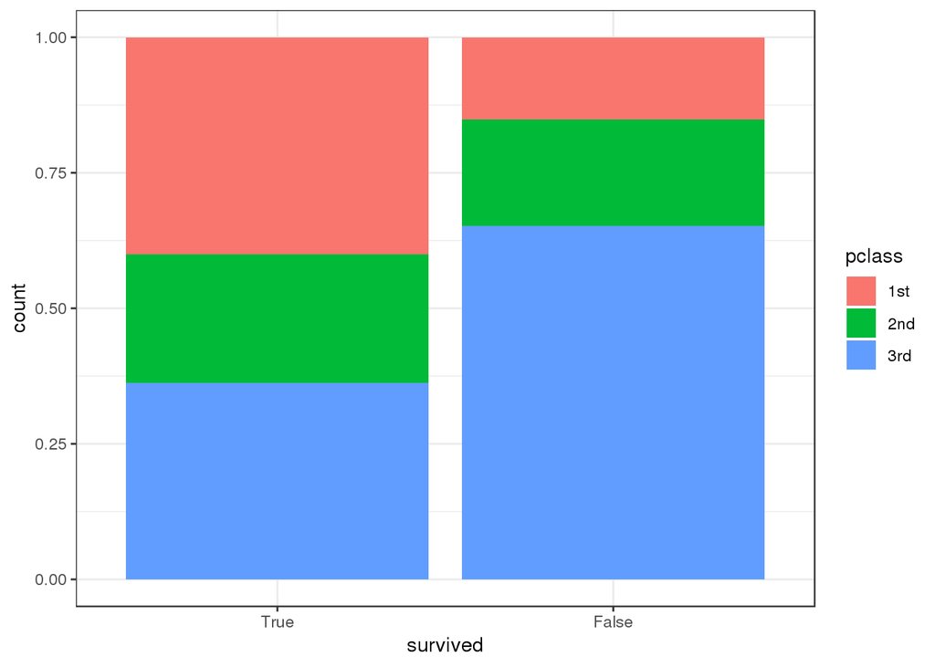

```r
?TITANIC3

TITANIC3 %>%
  mutate(survived = factor(survived, levels = c(1,0), labels = c("True", "False"))) %>%
  ggplot(aes(x=survived, fill = pclass)) +
    geom_bar(position = "fill") +
    theme_bw()
```

$X^2 = \frac{\sum(0-E)^2}{E}$

```r
data <- TITANIC3 %>%
  mutate(survived = factor(survived, levels = c(1,0), labels = c("True", "False")))

T1 <- table(data$pclass, data$survived)



##TITANIC3 %>%
##  mutate(survived = factor(survived, levels = c(1,0), labels = c("True", "False"))) %>%
##  select(pclass, survived) %>%
##  table()
T1
```

```
##
##       True False
##   1st  200   123
##   2nd  119   158
##   3rd  181   528
```

```r
vals <- addmargins(T1)

expected <- matrix(nrow=nrow(vals)-1, ncol = ncol(vals)-1)

for(i in 1:(nrow(vals)-1)) {
  for (j in 1:(ncol(vals)-1)) {
    expected[[i,j]] <- vals[[i, ncol(vals)]] * vals[[nrow(vals),j]]/vals[[nrow(vals), ncol(vals)]]
    colnames(expected) <- colnames(vals)[1:ncol(expected)]
    rownames(expected) <- rownames(vals)[1:nrow(expected)]

  }
}
expected
```

```
##         True    False
## 1st 123.3766 199.6234
## 2nd 105.8060 171.1940
## 3rd 270.8174 438.1826
```

```r
chi_obs_stat <- chisq.test(T1)$stat
chi_obs_stat
```

```
## X-squared
##  127.8592
```

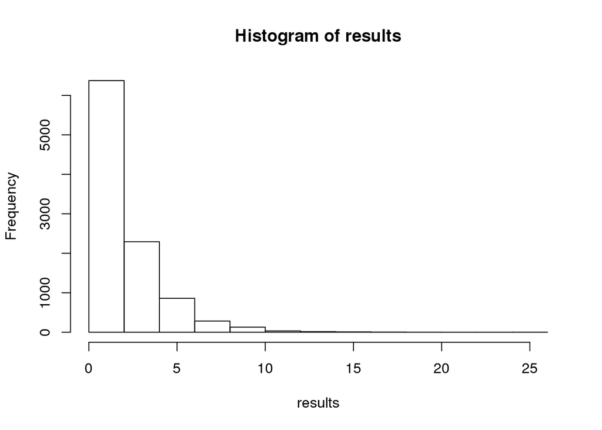

```r
sims <- 10000
results <- numeric(sims)
for(i in 1:sims) {
  T2 <- xtabs(~pclass + sample(survived), data = data)
  results[i] <- chisq.test(T2,correct = FALSE)$stat
}

hist(results)
```

Find the p-value

```r
pvalueSIM <- (sum(results >= chi_obs_stat) + 1)/(sims + 1)
pvalueSIM
```

```
## [1] 9.999e-05
```

Use `infer`

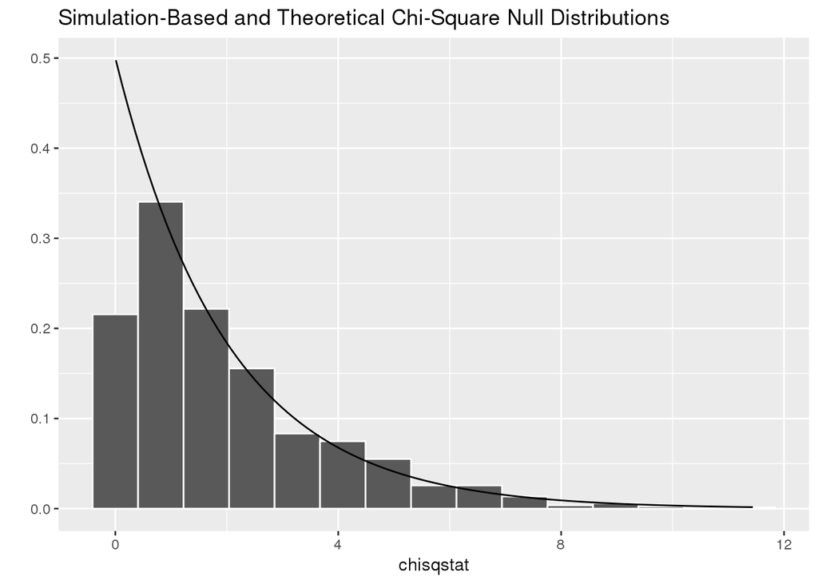

```r
T3 <- data %>%
  specify(pclass ~ survived) %>%
  hypothesize(null = "independence") %>%
  generate(reps = 1000, type = "permute") %>%
  calculate(stat = "Chisq")

visualize(T3, method = "both")
```

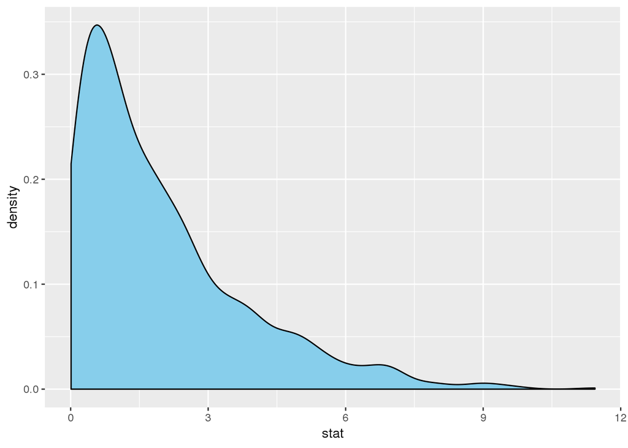

```r
ggplot(T3, aes(x=stat)) +
  geom_density(fill = "skyblue")
```

```r
#t <- t.test(pclass ~ survived, data = data)
#obs_stat <- t$stat
get_pvalue(T3, chi_obs_stat, direction = "greater")
```

```
## # A tibble: 1 x 1
##   p_value
##     <dbl>
## 1       0
```

# What is a p-value

> The probability that what we observe is greater than or equal to the observation we made if we assume the null hypothesis is true.

# Consider Testing

$H_0: p_1 - p_2 = 0$

```r
data %>%
  dplyr::select(sex, survived) %>%
  table() %>%
  addmargins()
```

```
##         survived
## sex      True False  Sum
##   female  339   127  466
##   male    161   682  843
##   Sum     500   809 1309
```

```r
data %>%
  dplyr::select(sex, survived) %>%
  table() %>%
  prop.table(1)
```

```
##         survived
## sex           True     False
##   female 0.7274678 0.2725322
##   male   0.1909846 0.8090154
```

```r
prop.test(x = c(161, 339), n = c(843, 466), alternative = "less", correct = FALSE)
```

```
##
##  2-sample test for equality of proportions without continuity
##  correction
##
## data:  c(161, 339) out of c(843, 466)
## X-squared = 365.89, df = 1, p-value < 2.2e-16
## alternative hypothesis: less
## 95 percent confidence interval:
##  -1.0000000 -0.4959006
## sample estimates:
##    prop 1    prop 2
## 0.1909846 0.7274678
```

Use `infer`

[figure not shown]

```r
T4 <- data %>%
  specify(survived ~ sex, success = "True") %>%
  hypothesize(null = "independence") %>%
  generate(reps = 1000, type = "permute") %>%
  calculate(stat = "Chisq", order = c("male","female"))

visualize(T4, method = "both")
```

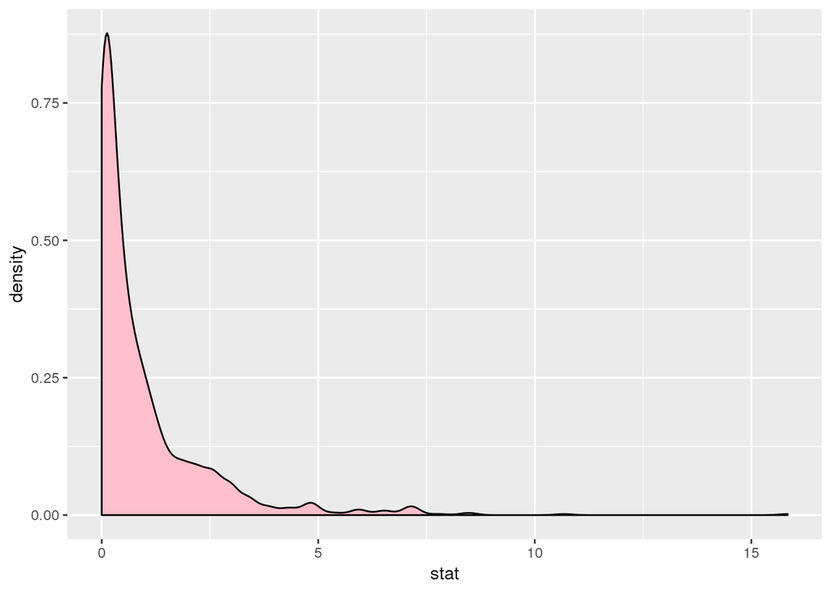

```r
ggplot(T4, aes(x=stat)) +
  geom_density(fill = "pink")
```

```r
#t <- t.test(pclass ~ survived, data = data)
#obs_stat <- t$stat
get_pvalue(T4, chi_obs_stat, direction = "greater")
```

```
## # A tibble: 1 x 1
##   p_value
##     <dbl>
## 1       0
```

```r
phatmale <- 161/843
phatfemale <- 339/466
phatp <- (161 + 339)/(843+466)
zobs <- (phatmale - phatfemale) / sqrt(phatp*(1-phatp)/843+phatp*(1-phatp)/466)
zobs
```

```
## [1] -19.12817
```

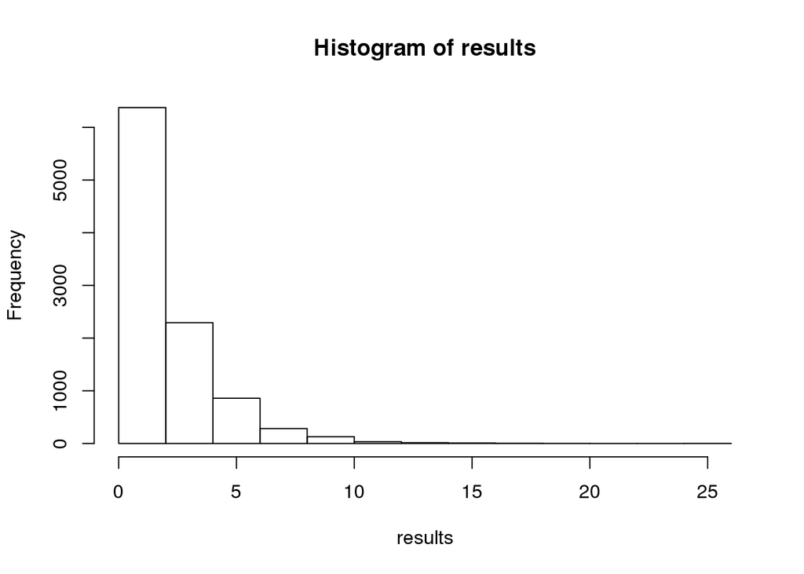

```r
sims <- 1000
results2 <- numeric(sims)
for(i in 1:sims) {
  T6 <- xtabs(~sex + sample(survived), data = data)
  results2[i] <- chisq.test(T6,correct = FALSE)$stat
}

pvalue <- (sum(results2 >= chisq.test(table(data$sex, data$survived))$stat))

hist(results)
```

```r
DP <- c(67, 76, 57, 48, 73, 79)
MDP <- matrix(data = DP, nrow = 2, byrow = TRUE)
dimnames(MDP) <- list(Pop = c("Drug", "Placebo"), Status = c("Improve", "No Change", "Worse"))
TDP <- as.table(MDP)
TDP
```

```
##          Status
## Pop       Improve No Change Worse
##   Drug         67        76    57
##   Placebo      48        73    79
```

```r
NT <- TDP %>%
  broom::tidy() %>%
  uncount(n)

NT
```

```
## # A tibble: 400 x 2
##    Pop   Status
##    <chr> <chr>
##  1 Drug  Improve
##  2 Drug  Improve
##  3 Drug  Improve
##  4 Drug  Improve
##  5 Drug  Improve
##  6 Drug  Improve
##  7 Drug  Improve
##  8 Drug  Improve
##  9 Drug  Improve
## 10 Drug  Improve
## # ... with 390 more rows
```